# Trabajo Practico

Primero cargamos las librerias necesarias:

```r
library(quantreg);
library(readxl); # para leer archivos xml, pero vamos a usar el paquete eph
library(eph);
library(dplyr);
library(tidyr)
library(ggplot2)
```

# Pregunta 1

### a.

Hacemos las restricciones, y calculamos la variable anios_educacion en funcion de CH14 (ultimo anio de aprobacion), luego lo mismo para experiencia potencial y su cuadrado.

Hacemos una limpieza: como quitar los valores de anios_educacion por encima de 100, ya que son valores que provienen de educacion especial o Ns/Nr

```r
base2024 <- get_microdata(year = 2024) # para leer usando el paquete eph
#base2024 <- read_excel('EPH_usu_1er_Trim_2024_xlsx/usu_individual_T124.xlsx')

base <- base2024[base2024$P21>0 &      ## asalariados
                       base2024$CH03 == 01 & ## jefes de hogar
                       base2024$CH04 == 1 &  ## varones
                       25 <= base2024$CH06 & ## edades
                       base2024$CH06 <= 65,]

# renombramos las variables que usamos, para mas claridad
base <-base %>%
        rename(wage = P21,  ubicacion = AGLOMERADO, est_civil = CH07, edad = CH06)

# calculamos anios de educacion (anios_edu), experiencia potencial (exp_pot)
anios_prev <- c(0, 0, 6, 6, 9, 12, 12, 18)
anios_post <- c(0, 6, 9, 12, 12, 15, 18, 22)

base1 <- base %>%
  mutate(
    # Asignar el número de años en base al nivel de educación y condición de finalización
    anios_edu = ifelse(CH13 == 1,
                      anios_post[CH12 + 1],  # +1 para ajustar al índice en R
                      anios_prev[CH12 + 1] + as.numeric(CH14)),

    # Calcular la experiencia potencial y su cuadrado
    exp_pot = edad - anios_edu - 6,
    exp_pot_2 = exp_pot^2
  )

base1 <- base1[complete.cases(base1[, c("exp_pot")]), ] # nos quitamos los na's.
base1 <- base1[! (base1$anios_edu > 100),]
```

```r
data1 <- log(base1$wage)
data2 <- base1$wage

par(mfrow = c(1, 2))

# Graficar el primer histograma
hist(data1, col = "skyblue", main = "Histograma lwage", xlab = "Valores de lwage", ylab = "Frecuencia")

# Graficar el segundo histograma
hist(data2, col = "salmon", main = "Histograma wage", xlab = "Valores de wage", ylab = "Frecuencia")
```

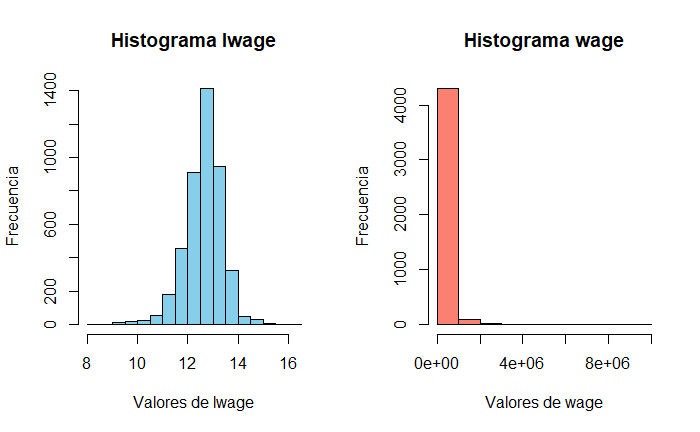

```r
# Resetear la configuración para evitar que afecte otros gráficos
par(mfrow = c(1, 1))
```

```r
#hist(log(base1$wage),main = "Histograma lwage",xlab = "log(wage)")
```

Visualmente se observa cierta normalidad en los datos luego de hacer la transformacion a **lwage**, esto no es asi con los valore crudos de **wage**. Mas adelante se hace un analisis tomando en cuenta ambos enfoques con 2 modelos donde se encontrar diferencias.

```r
par(mfrow = c(1, 2))

# Graficar el primer histograma
plot(base1$anios_edu, log(base1$wage),xlab= "Años de educación",ylab = "lwage")

# Graficar el segundo histograma
plot(base1$anios_edu, base1$wage,xlab= "Años de educación",ylab = "wage")
```

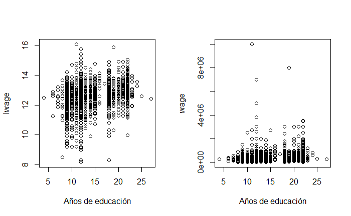

```r
# Resetear la configuración para evitar que afecte otros gráficos
par(mfrow = c(1, 1))
```

### Realizamos el modelo lineal

AGLOMERADO -> ubicacion CH07 -> estado civil CH06 -> edad

##### Modelo 1

$$log(wage) = \text{anios_ed} +
\text{exp_pot} + \text{exp_pot}^2 + ubicacion (dummie) +
\text{estado_civil} + edad$$

##### Modelo 2

$$log(wage) = educacion (dummie) +
\text{exp_pot} + \text{exp_pot}^2 + ubicacion (dummie) +
\text{estado_civil} + edad$$

```r
reg1 <- lm(log(wage)~ anios_edu + exp_pot + exp_pot_2 + edad + as.factor(ubicacion) + as.factor(est_civil), data=base1)
reg2 <- lm(log(wage)~ as.factor(NIVEL_ED) + exp_pot + exp_pot_2 + edad + as.factor(ubicacion) + as.factor(est_civil), data=base1)

summ_reg1 <- summary(reg1)
summ_reg2 <- summary(reg2)

# Extraer los coeficientes, errores estándar, valores t y p-valores del resumen del modelo
coef_reg1 <- coef(summ_reg1)
coef_reg2 <- coef(summ_reg2)

# Filtrar las filas de los coeficientes que te interesan
coef_interes_reg1 <- coef_reg1[c("anios_edu", "exp_pot"), ]
coef_interes_reg2 <- coef_reg2[grep("NIVEL_ED", rownames(coef_reg2)), ]
```

```r
x <- c("Primario completo","Secundario incompleto","Secundario completo",
       "Universitario incompleto","Universitario completo","Sin instruccion")
y <- coef_interes_reg2[,1]
pv <- coef_interes_reg2[,4]

# Crear el gráfico base
plot(1:length(x), y, type = "b", pch = 19, col = "blue", xaxt = "n",
     xlab = "", ylab = "Coeficiente estimado",
     xlim = c(0, length(x) + 1),
     main = "Efecto del Nivel Educativo sobre lwage")

# Añadir una línea horizontal en y = 0 para referencia
abline(h = 0, col = "red", lty = 2)
```

```r
# Añadir las etiquetas del eje X inclinadas
axis(1, at = 1:length(x), labels = FALSE)  # Ocultar etiquetas predeterminadas
text(1:length(x), par("usr")[3] - 0.05,  # Ajuste para desplazar las etiquetas
     labels = x, srt = 45, adj = 1, xpd = TRUE, cex = 0.8)
```

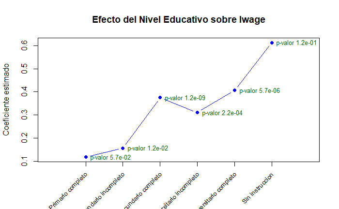

```r
# Filtrar los valores válidos para evitar NA en los p-valores
valid_indices <- which(!is.na(y))

# Añadir los p-valores junto a sus respectivos puntos en el gráfico
text(valid_indices, y[valid_indices],
     labels = paste("p-valor", format(pv[valid_indices], digits = 2)),
     pos = 4, cex = 0.8, col = "darkgreen")
```

La variación considerable en los coeficientes de las variables dummie *NIVEL_ED* sugiere que el efecto en el logaritmo de los salarios (*log(wage)*) de cada nivel educativo no es constante. Es decir parece haber un efecto no lineal de la educacion sobre lwage.

Esto indica que el retorno económico de completar un nivel educativo cambia significativamente dependiendo de qué nivel se está comparando. Por ejemplo, pasar de primario completo a secundario completo parece tener un retorno mayor que otros niveles, sugiriendo que las personas que completan el secundario pueden obtener un salario significativamente más alto que aquellos que solo completan el primario.

Los coeficientes para secudario incompleto, completo y universitario incompleto y completo, son todos significativos, en especial el 4 (secundario completo), lo que respalda la idea de que esos niveles educativos tienen un impacto positivo y relevante en los salarios. Por otro, si bien el coeficiente de la categoria *Sin instruccion* es alto en comparacion, no es significativo, por tanto no es influyente para estimar lwage.

La variación en los coeficientes y su significancia sugiere que el impacto de la educación sobre los salarios no es lineal. Esto es consistente con la idea de que ciertos niveles de educación (como completar la secundaria o la educación superior) pueden ofrecer ventajas salariales más significativas que simplemente tener un año más de educación.

```r
anova(reg1,reg2)
```

```
Analysis of Variance Table

Model 1: log(wage) ~ anios_edu + exp_pot + exp_pot_2 + edad + as.factor(ubicacion) +
    as.factor(est_civil)
Model 2: log(wage) ~ as.factor(NIVEL_ED) + exp_pot + exp_pot_2 + edad +
    as.factor(ubicacion) + as.factor(est_civil)
  Res.Df    RSS Df Sum of Sq      F    Pr(>F)
1   4388 2002.9
2   4382 1961.2  6    41.718 15.536 < 2.2e-16 ***
---
Signif. codes:  0 ‘***’ 0.001 ‘**’ 0.01 ‘*’ 0.05 ‘.’ 0.1 ‘ ’ 1
```

La prueba **ANOVA** de ambos modelos, dio un p-valor menor a 0.05, suponiendo verdaderas las hipotesis necesaria de *ANOVA*, tenemos que cuando controlamos por las variables control (valga la redundancia) el nivel educativo maximo alcanzado como variable dummie de cada persona resulta significativo, contra la variable continua. Por tanto esto sugiere un efecto no lineal de la educacion sobre lwage.

### Intervalo de confianza de $\beta_1$ (anios_ed)

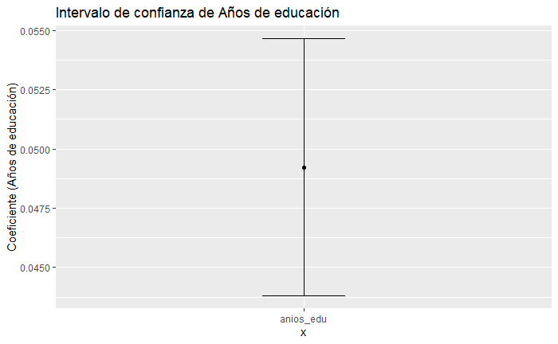

```r
coef_df <- data.frame(estimate = coef(reg1)["anios_edu"], confint_lower = confint(reg1)["anios_edu", 1], confint_upper = confint(reg1)["anios_edu", 2])

ggplot(coef_df, aes(x = "anios_edu", y = estimate)) +
  geom_point() +
  geom_errorbar(aes(ymin = confint_lower, ymax = confint_upper), width = 0.2) +
  labs(title = "Intervalo de confianza de Años de educación", y = "Coeficiente (Años de educación)")
```

```r
print(confint(reg1)[2,] )
```

```
     2.5 %     97.5 %
0.04381166 0.05464839
```

### b.

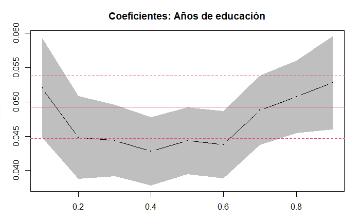

```r
regq1 <- rq(log(wage)~ anios_edu + exp_pot + exp_pot_2 + as.factor(ubicacion) + as.factor(est_civil),data=base1,tau = 1:9/10,ci = FALSE)
summregq1 <- summary(regq1,se="ker")
plot(summregq1,parm=2,main ="Coeficientes: Años de educación",xlab ="tau's",ylab = "coef ") # con param =2 le decimos que queremos el grafico de valores e intervalos de confianza de años de educacion.
```

Para cuantiles bajos (τ cercanos a 0.1), el coeficiente de años_ed es más alto, lo que indica que el efecto marginal de la educación es mayor entre las personas con ingresos más bajos. En otras palabras, para este grupo, cada año adicional de educación tiene un impacto más fuerte en el aumento de los ingresos. Esto tiene sentido dado que estos individuos, al tener ingresos relativamente bajos, podrían beneficiarse más de la educación en términos de movilidad económica.

A medida que τ se aproxima a 0.5 (mediana de la distribución), el coeficiente de años_ed disminuye, lo que sugiere que, en la mediana de los ingresos, el impacto de la educación es menos pronunciado. Es decir, el efecto marginal de la educación se atenúa en este grupo, lo cual podría indicar que otros factores además de la educación juegan un rol más importante en la determinación de los ingresos.

Finalmente, para los cuantiles altos (τ cercanos a 0.9), el coeficiente de años_ed vuelve a aumentar, lo que sugiere que, para aquellos con ingresos más altos, la educación sigue siendo un factor determinante. Esto podría reflejar que en los niveles más altos de la distribución de ingresos, los años de educación siguen siendo cruciales para alcanzar los ingresos más elevados, probablemente debido a la acumulación de capital humano especializado o credenciales educativas superiores.

Yendo a la pregunta del 1.b Para los individuos en los cuantiles bajos y altos, un año adicional de educación tiene un impacto significativo en el aumento de los ingresos, lo que sugiere que la educación es una vía importante para mejorar su situación económica. Esto puede deberse a que un año más de formación amplía sus oportunidades laborales y su potencial de ingresos de manera considerable.

La comparacion grafica que veo es que al usar el modelo de regresion lineal estamos calculando la media de la log de los ingresos y no estamos puediendo dale demaciada interpretabilidad al coeficiente, y como en este modelo no presenta este problema, podemos dar mas interpretabilidad.

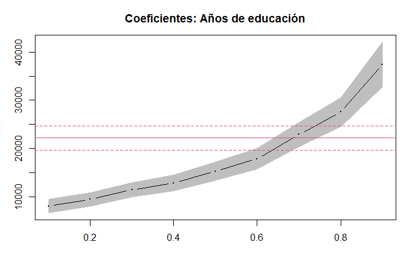

```r
regq1 <- rq(wage~ anios_edu + exp_pot + exp_pot_2 + as.factor(ubicacion) + as.factor(est_civil),data=base1,tau = 1:9/10,ci = FALSE)
summregq1 <- summary(regq1,se="ker")
plot(summregq1,parm=2,main ="Coeficientes: Años de educación",xlab ="tau's",ylab = "coef ") # con param =2 le decimos que queremos el grafico de valores e intervalos de confianza de años de educacion.
```

Para el caso de un Modelo, con la variable dependiente **wage**, se obtuvo que el coeficiente siempre crece en funcion de $\tau$ pareciera ser de manera exponencial, concluimos que el efecto marginal de los anios de educacion sera creciente en funcion de los ingresos de las personas.

Este cambio en el analisis, se debe al cambio del modelo, en termino de la variable dependiente al hacer el cambio de escala

```r
summregq2 <- summary(regq1,se="boot",R=100)
plot(summregq2,parm=2,main ="Coeficientes: Años de educación",xlab ="tau's",ylab = "coef ")
```

```r
summregq3 <- summary(regq1,se="iid")
plot(summregq3,parm=2,main ="Coeficientes: Años de educación",xlab ="tau's",ylab = "coef ")
```

Habia dicidido no mostrar con los otros metodos (iid boot) por que no vi cambios significativos.